# RNA-seq Analysis of OAC organoids

2025-12-04

This script will be used as a review of the RNA-seq analysis of our OAC-derived organoids. In this case, we are broadly aiming to gauge the phenotypic heterogeneity of our organoids, and whether any interesting features could be observed to explain it.

```r
library(readxl) # read Excel files
library(tidyverse) # for data table manipulation
library(SummarizedExperiment) # for SummarizedExperiment object generation
```

```r
library(ggplot2) # plotting
library(fgsea) # for fast gene-set enrichment analysis
library(ensembldb) # gene information
library(EnsDb.Hsapiens.v79) # gene information
library(DESeq2) # differentatial expression analysis
library(sva) # batch correction
```

# Unsupervised Analysis

As an initial indication of the heterogeneity of our OAC organoids, we can simply project them onto a PCA and see if a clinical feature (e.g. stage) is associated.

```r
# Load metadata (this only contains normal and BO organoids - the remainder of the cohort is OAC)
meta.seq <- read.csv('Data/case_sex_spec_pheno_source_site_pass_batch_seq_org_cases.csv') %>%
  dplyr::filter(strategy == 'rna' &
           specimen_source == 'organoid' &
           specimen_phenotype %in% c('oac','OAC','tumour') &
           !(sequencing_batch %in% c('SLX-19631','SLX-21330'))) # only 1 organoid per batch

# Fix sequence IDs
meta.seq$sequence_id <- sapply(meta.seq$sequence_id, function(x) str_replace(x,pattern='1672_',replacement=''))
meta.seq$sequence_id <- sapply(meta.seq$sequence_id, function(x) str_replace(x,pattern='1441_',replacement=''))

index.1672_include <- which(meta.seq$sequence_id %in% c('WTSI-OESO_198_1pre','WTSI-OESO_211_1pre','WTSI-OESO_224_1pre'))
meta.seq$sequence_id[index.1672_include] <- paste0('1672_',meta.seq$sequence_id[index.1672_include])

# # Add clinical information, and merge this with metadata
# meta.clin <- read_excel('Data/query_standard_cohort_2025-03-25_16-27-46.xlsx') %>%
#   dplyr::filter(!duplicated(`OCCAMS ID`)) %>%
#   dplyr::filter(`OCCAMS ID` != 'OCCAMS/AH/467') %>% # no WGS for this patient - likely blood mismatch
#   dplyr::select(`OCCAMS ID`,`PS TStage Primary Tumour Final Pretreatment Staging`,
#                 `RP Tumour Grading Differentiation Status`,`TRNC Chemotherapy Treatment Protocol`)
# names(meta.clin) <- c('case_id','Stage','DifferentiationStatus','ChemoTreatment')
meta.clin <- read_excel('Data/Copy of Org_Clinical_demo_For_DJ.xlsx') %>%
  dplyr::filter(!is.na(Age)) %>%
  dplyr::filter(ID != 'OCCAMS/AH/467') %>%
  mutate(Stage = sapply(`Surgical TNM`, function(x) strsplit(x,split='N')[[1]][1]))

# # Fix staging nomenclature
# meta.clin$Stage[meta.clin$Stage == 'tumour_invades_adventitia'] <- 'T3'
# meta.clin$Stage[meta.clin$Stage == 'tumour_invades_muscularis_propria'] <- 'T2'

meta <- merge(x = meta.seq, y = meta.clin, by.x = 'case_id', by.y = 'ID')
```

## Collate counts data

Now that we have defined the organoids to be extracted, we can now collate all of our transcriptomic data, and subset on it to specifically highlight OAC organoids.

```r
# Create counts matrices (raw and TPM)
#   Include sequence_id as a column name
#   These will eventually be replaced by matched specimen IDs
counts_list <- counts.TPM_list <- list()
files.rnaseq <- list.files(path = 'Data', full.names = TRUE, pattern = 'rpkm_tpm.txt')
files.rnaseq <- files.rnaseq[!grepl(pattern = 'SLX', files.rnaseq)]

for (file in files.rnaseq) {

  file.counts <- read.table(file, header = TRUE)

  # Isolate specimen ID
  file.sequence_id <- strsplit(strsplit(file, split='/')[[1]][2], split='__')[[1]][1]

  # Add to counts lists
  counts_list[[file.sequence_id]] <- file.counts$readcounts_union
  counts.TPM_list[[file.sequence_id]] <- file.counts$TPM_union

}

# Collate lists into count matrices (and specifically extract those in meta$sequence_id)
counts <- do.call(bind_cols, counts_list[meta$sequence_id]) %>% as.matrix
counts.TPM <- do.call(bind_cols, counts.TPM_list[meta$sequence_id]) %>% as.matrix

# Add rownames(genes)
rownames(counts) <- rownames(file.counts)
rownames(counts.TPM) <- rownames(file.counts)

# Generate col_data and row_data, for eventual collation into a SummatizedExperiment object
col_data <- meta %>% dplyr::select('sequence_id','case_id','passage','sequencing_batch',
                                   'Stage','Histopathological grading','Chemotherapy regimen') %>%
  as.data.frame
rownames(col_data) <- col_data$sequence_id

# Subset for earliest-passage PDO
col_data <- col_data %>%
  arrange(as.numeric(passage)) %>%
  group_by(case_id) %>%
  slice_head() %>% as.data.frame
rownames(col_data) <- col_data$sequence_id
counts <- counts[,rownames(col_data)]
counts.TPM <- counts.TPM[,rownames(col_data)]

row_data <- ensembldb::select(
  EnsDb.Hsapiens.v79,
  keys = rownames(counts),
  keytype = 'GENEID',
  columns = c('GENEID','SYMBOL')
)
counts <- counts[row_data$GENEID,]
counts.TPM <- counts.TPM[row_data$GENEID, ]

# Create SummarizedExperiment object
se <- SummarizedExperiment(assays = list(counts = counts),
                           rowData = row_data, colData = col_data)
```

On this, we can simply begin by conducting a principal component analysis. This will require conversion to a DESeq format, followed by batch correction (for sequencing batch) and variance stabilising transformation, before PCA.

```r
# Create DESeq2 object
dds <- DESeqDataSet(se, design = ~ 1) # No direct comparisons

# Remove lowly-expressed genes and estimate size factors
dds <- dds[apply(counts(dds), 1, function(x) mean(x>50)>.25), ] # remove genes with <50 reads in >25% organoids
dds <- estimateSizeFactors(dds)

# Variance stabilising transformation
vsd <- vst(dds, blind = FALSE)

# batch correction
vsd_combat.data <- ComBat(dat = assay(vsd), batch = vsd$sequencing_batch)
```

```
## Found 34 genes with uniform expression within a single batch (all zeros); these will not be adjusted for batch.
```

```
## Found3batches
```

```
## Adjusting for0covariate(s) or covariate level(s)
```

```
## Standardizing Data across genes
```

```
## Fitting L/S model and finding priors
```

```
## Finding parametric adjustments
```

```
## Adjusting the Data
```

```
## using ntop=1000 top features by variance
```

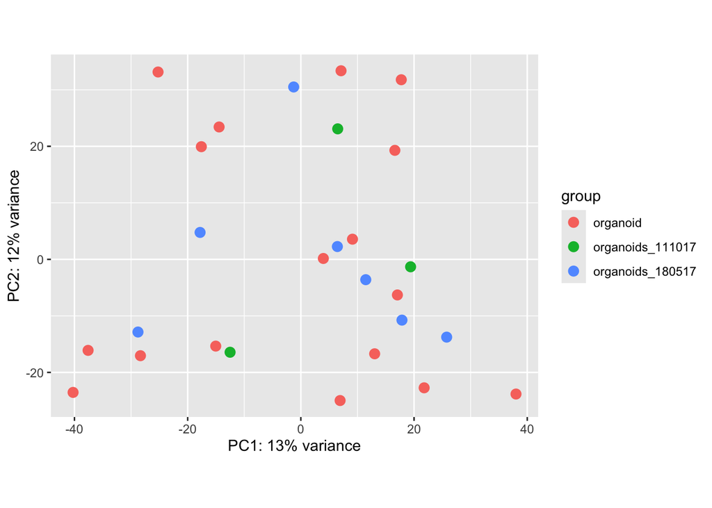

```r
vsd_combat <- vsd; assay(vsd_combat) <- vsd_combat.data

plotPCA(vsd_combat, intgroup = 'sequencing_batch', ntop = 1000)
```

Since there seems to be plenty of heterogeneity displayed within these organoids, we can run fgsea on the PCA loadings to get a sense of cancer hallmark processes which may be driving it.

```r
# Re-run principal component analysis on top 1000 variable genes
var_genes <- apply(assay(vsd_combat), 1, var)
vsd_combat.pca_plot <- vsd_combat[var_genes >= sort(var_genes, decreasing = TRUE)[1000], ]

pca.vsd_combat <- prcomp(t(assay(vsd_combat.pca_plot)), center = TRUE)
print(summary(pca.vsd_combat))
```

```
## Importance of components:
##                            PC1     PC2      PC3      PC4      PC5      PC6
## Standard deviation     20.8142 19.7695 16.09648 15.11900 14.04461 13.60902
## Proportion of Variance  0.1281  0.1156  0.07664  0.06761  0.05834  0.05478
## Cumulative Proportion   0.1281  0.2437  0.32038  0.38799  0.44633  0.50111
##                             PC7      PC8      PC9     PC10     PC11     PC12
## Standard deviation     13.12326 11.66984 11.11159 10.91104 10.64375 10.14868
## Proportion of Variance  0.05094  0.04028  0.03652  0.03521  0.03351  0.03046
## Cumulative Proportion   0.55205  0.59233  0.62885  0.66407  0.69757  0.72804
##                           PC13    PC14    PC15    PC16    PC17    PC18    PC19
## Standard deviation     9.97310 9.80975 9.79236 9.34226 8.90580 8.62686 8.52437
## Proportion of Variance 0.02942 0.02846 0.02836 0.02582 0.02346 0.02201 0.02149
## Cumulative Proportion  0.75746 0.78592 0.81428 0.84010 0.86356 0.88557 0.90706
##                          PC20    PC21    PC22    PC23    PC24    PC25    PC26
## Standard deviation     8.1606 7.89942 7.56852 7.26441 6.53282 4.44678 3.56408
## Proportion of Variance 0.0197 0.01846 0.01694 0.01561 0.01262 0.00585 0.00376
## Cumulative Proportion  0.9268 0.94522 0.96216 0.97777 0.99039 0.99624 1.00000
##                             PC27
## Standard deviation     4.618e-14
## Proportion of Variance 0.000e+00
## Cumulative Proportion  1.000e+00
```

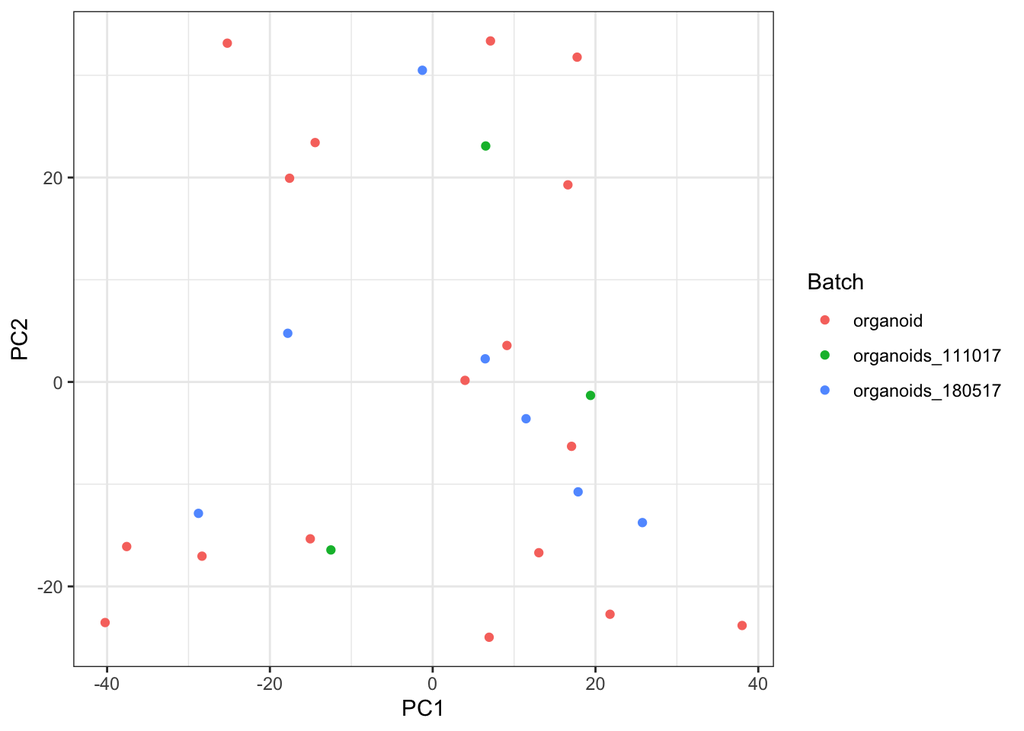

```r
df.pca <- data.frame(
  PC1 = pca.vsd_combat$x[,'PC1'], PC2 = pca.vsd_combat$x[,'PC2'],
  Stage = vsd_combat.pca_plot$Stage, Batch = vsd_combat.pca_plot$sequencing_batch,
  Chemotherapy = vsd_combat.pca_plot$`Chemotherapy regimen`
)

# Check sequencing batch
ggplot(df.pca, aes(x = PC1, y = PC2, color = Batch)) + theme_bw() + geom_point()
```

```r
df.pca$Stage[df.pca$Stage %in% c('T1a','T1b')] <- 'T1'
df.pca$Stage[df.pca$Stage %in% c('T4a','T4b')] <- 'T4'

# Check Stage
pdf('Results/OrganoidsOAC_RNAseq_PCAbyStage.pdf', width=7, height=7)
ggplot(df.pca, aes(x = PC1, y = PC2, color = Stage, shape = Chemotherapy)) + theme_bw() +
  geom_point(size = 2.5) +
  labs(x = 'PC1: 12.8% variance', y = 'PC2: 11.6% variance') +
  theme(legend.position = 'top', legend.title = element_blank()) +
  scale_color_manual(values = c('gray70','yellow2','gold','orange','orangered'))
dev.off()
```

Now that we have our principal components, we can check how cancer hallmarks contribute to their heterogeneity using gene set enrichment analysis

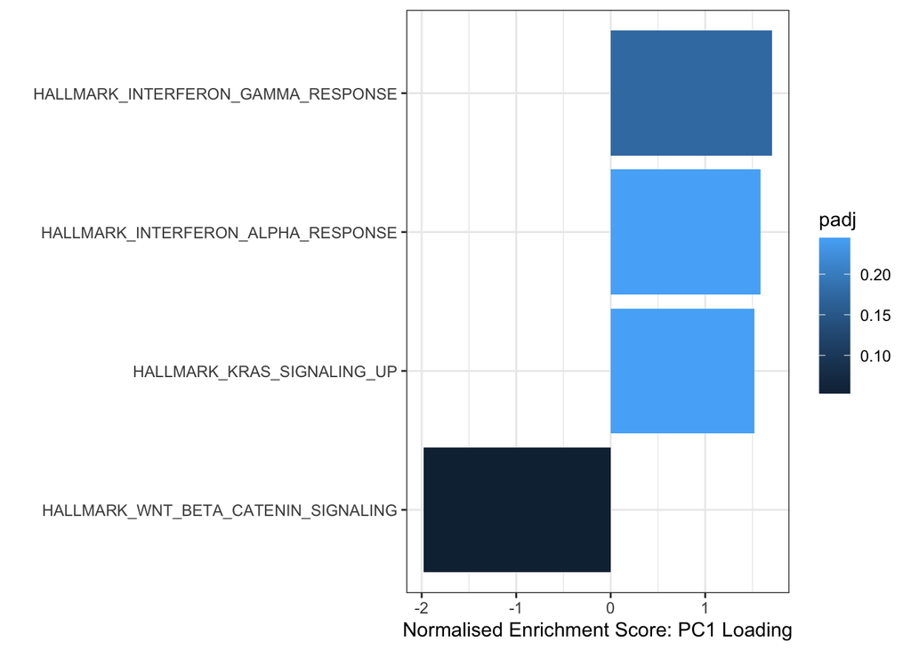

```r
# Load in hallmark gene sets (Hs.H)
load('Data/human_H_v5p2.rdata')

# Starting with PC1, we can obtain the EntrezIDs for ranked contributors and do fgsea
df.pc1 <- data.frame(EnsemblID = rownames(pca.vsd_combat$rotation), PC1 = pca.vsd_combat$rotation[,'PC1'])
entrez = ensembldb::select(
  EnsDb.Hsapiens.v79,
  keys = df.pc1$EnsemblID,
  columns = c('GENEID','ENTREZID'),
  keytype = 'GENEID')
df.pc1 <- merge(x = df.pc1, y = entrez, by.x = 'EnsemblID', by.y = 'GENEID')
df.pc1 <- df.pc1 %>% dplyr::filter(!duplicated(EnsemblID) &
                                     !is.na(ENTREZID))

# Create ranks
df.pc1 <- df.pc1 %>% arrange(PC1)
ranks <- df.pc1$PC1; names(ranks) <- df.pc1$ENTREZID

# Run fgsea
set.seed(123)
res.fgsea <- fgsea(pathways = Hs.H, stats = ranks)

df_res.fgsea <- res.fgsea %>% as.data.frame() %>%
  dplyr::filter(padj < 0.4) %>% arrange(NES) %>%
  mutate(pathway = factor(pathway, levels = pathway))
ggplot(df_res.fgsea, aes(x = NES, y = pathway, fill = padj)) + theme_bw() +
  geom_bar(stat = 'identity') +
  labs(x = 'Normalised Enrichment Score: PC1 Loading', y ='')
```

```r
ggsave(filename = 'Results/OrganoidsOAC_RNAseq_fgsea_PC1.pdf', height = 4)
```

For the sake of completion, we can check PC2 as well.

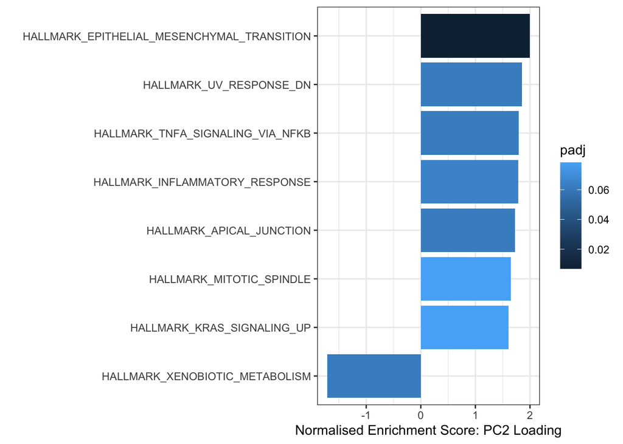

```r
# Starting with PC1, we can obtain the EntrezIDs for ranked contributors and do fgsea
df.pc2 <- data.frame(EnsemblID = rownames(pca.vsd_combat$rotation), PC2 = pca.vsd_combat$rotation[,'PC2'])
entrez = ensembldb::select(
  EnsDb.Hsapiens.v79,
  keys = df.pc2$EnsemblID,
  columns = c('GENEID','ENTREZID'),
  keytype = 'GENEID')
df.pc2 <- merge(x = df.pc2, y = entrez, by.x = 'EnsemblID', by.y = 'GENEID')
df.pc2 <- df.pc2 %>% dplyr::filter(!duplicated(EnsemblID) &
                                     !is.na(ENTREZID))

# Create ranks
df.pc2 <- df.pc2 %>% arrange(PC2)
ranks <- df.pc2$PC2; names(ranks) <- df.pc2$ENTREZID

# Run fgsea
set.seed(123)
res.fgsea <- fgsea(pathways = Hs.H, stats = ranks)

df_res.fgsea <- res.fgsea %>% as.data.frame() %>%
  dplyr::filter(padj < 0.1) %>% arrange(NES) %>%
  mutate(pathway = factor(pathway, levels = pathway))
ggplot(df_res.fgsea, aes(x = NES, y = pathway, fill = padj)) + theme_bw() +
  geom_bar(stat = 'identity') +
  labs(x = 'Normalised Enrichment Score: PC2 Loading', y ='')
```

```r
ggsave(filename = 'Results/OrganoidsOAC_RNAseq_fgsea_PC2.pdf', height = 4)
```

To align with PDOs treated with a CDK4/6 inhibitor (abemaciclib), we can compare their responses with other potential markers of response. We extract the TPM-normalised values here.

```r
# Re-create se.tpm file (this will make things easier)
se.tpm <- SummarizedExperiment(assays = list(counts.TPM = counts.TPM),
                               rowData = row_data, colData = col_data)

# Subset for CDKi-treated PDOs, and select the earliest passages
se.tpm <- se.tpm[,se.tpm$case_id %in% c('OCCAMS/AH/277','OCCAMS/AH/401','OCCAMS/AH/429','OCCAMS/AH/535')]
se.tpm_col = colData(se.tpm) %>% as.data.frame

# Add relevant genes to se.tpm_col
se.tpm_col$RB1_TPM = assay(se.tpm)[which(rowData(se.tpm)$SYMBOL == 'RB1'),]
se.tpm_col$RB1_vsd_combat = assay(vsd_combat)[which(rowData(vsd_combat)$SYMBOL == 'RB1'), se.tpm_col$sequence_id]

se.tpm_col$ESR1_TPM = assay(se.tpm)[which(rowData(se.tpm)$SYMBOL == 'ESR1'),]
# se.tpm_col$ESR1_vsd_combat = assay(vsd_combat)[which(rowData(vsd_combat)$SYMBOL == 'ESR1'), se.tpm_col$sequence_id]

se.tpm_col$CCNE1_TPM = assay(se.tpm)[which(rowData(se.tpm)$SYMBOL == 'CCNE1'),]
se.tpm_col$CCNE1_vsd_combat = assay(vsd_combat)[which(rowData(vsd_combat)$SYMBOL == 'CCNE1'), se.tpm_col$sequence_id]

write.csv(se.tpm_col, file = 'Results/OrganoidsOAC_treatedCDK46i_Markers.csv')
```